# **Milestone 1**

## **Data Dictionary**

The dataset contains the following features:

1. ID: Unique ID of each customer
2. Year_Birth: Customer’s year of birth
3. Education: Customer's level of education
4. Marital_Status: Customer's marital status
5. Kidhome: Number of small children in customer's household
6. Teenhome: Number of teenagers in customer's household
7. Income: Customer's yearly household income in USD
8. Recency: Number of days since the last purchase
9. Dt_Customer: Date of customer's enrollment with the company
10. MntFishProducts: The amount spent on fish products in the last 2 years
11. MntMeatProducts: The amount spent on meat products in the last 2 years
12. MntFruits: The amount spent on fruits products in the last 2 years
13. MntSweetProducts: Amount spent on sweet products in the last 2 years
14. MntWines: The amount spent on wine products in the last 2 years
15. MntGoldProds: The amount spent on gold products in the last 2 years
16. NumDealsPurchases: Number of purchases made with discount
17. NumCatalogPurchases: Number of purchases made using a catalog (buying goods to be shipped through the mail)
18. NumStorePurchases: Number of purchases made directly in stores
19. NumWebPurchases: Number of purchases made through the company's website
20. NumWebVisitsMonth: Number of visits to the company's website in the last month
21. AcceptedCmp1: 1 if customer accepted the offer in the first campaign, 0 otherwise
22. AcceptedCmp2: 1 if customer accepted the offer in the second campaign, 0 otherwise
23. AcceptedCmp3: 1 if customer accepted the offer in the third campaign, 0 otherwise
24. AcceptedCmp4: 1 if customer accepted the offer in the fourth campaign, 0 otherwise
25. AcceptedCmp5: 1 if customer accepted the offer in the fifth campaign, 0 otherwise
26. Response: 1 if customer accepted the offer in the last campaign, 0 otherwise
27. Complain: 1 If the customer complained in the last 2 years, 0 otherwise

**Note:** You can assume that the data is collected in the year 2016.

## **Important Notes**

- This notebook can be considered a guide to refer to while solving the problem. The evaluation will be as per the Rubric shared for each Milestone. Unlike previous courses, it does not follow the pattern of the graded questions in different sections. This notebook will give you a direction on what steps need to be taken in order to get a viable solution to the problem. Please note that this is just one way of doing this. There can be other 'creative' ways to solve the problem and we urge you to feel free and explore them as an 'optional' exercise.
- In the notebook, there are markdown cells called - Observations and Insights. It is a good practice to provide observations and extract insights from the outputs.
- The naming convention for different variables can vary. Please consider the code provided in this notebook as a sample code.
- All the outputs in the notebook are just for reference and can be different if you follow a different approach.
- There are sections called **Think About It** in the notebook that will help you get a better understanding of the reasoning behind a particular technique/step. Interested learners can take alternative approaches if they wish to explore different techniques.

# **Milestone 1**

### **Loading Libraries**

```python
!pip install yellowbrick
```

```python
# Libraries to help with reading and manipulating data
import numpy as np
import pandas as pd

# Libraries to help with data visualization
import matplotlib.pyplot as plt
import seaborn as sns

# To scale the data using z-score
from sklearn.preprocessing import StandardScaler

# To compute distances
from scipy.spatial.distance import cdist

# To perform K-means clustering and compute Silhouette scores
from sklearn.cluster import KMeans
from sklearn.metrics import silhouette_score

# To visualize the elbow curve and Silhouette scores
from yellowbrick.cluster import SilhouetteVisualizer

# Importing PCA
from sklearn.decomposition import PCA

# To encode the variable
from sklearn.preprocessing import LabelEncoder

# Importing TSNE
from sklearn.manifold import TSNE

# To perform hierarchical clustering, compute cophenetic correlation, and create dendrograms
from sklearn.cluster import AgglomerativeClustering
from scipy.cluster.hierarchy import dendrogram, linkage, cophenet

# To compute distances
from scipy.spatial.distance import pdist

# To import K-Medoids
from sklearn_extra.cluster import KMedoids

# To import Gaussian Mixture
from sklearn.mixture import GaussianMixture

# To import DBSCAN
from sklearn.cluster import DBSCAN

# To supress warnings
import warnings

warnings.filterwarnings("ignore")
```

### **Let us load the data**

```python
# loading the dataset
data = pd.read_csv("marketing_campaign.csv")
```

### **Check the shape of the data**

```python
# Print the shape of the data
data.shape
```

```
(2240, 27)
```

#### **Observations and Insights:**

The dataset comprises of **2240 rows** and **27 column** attributes.

### **Understand the data by observing a few rows**

```python
# View first 5 rows
data.head()
```

|  | ID | Year_Birth | Education | Marital_Status | Income | Kidhome | Teenhome | Dt_Customer | Recency | MntWines | ... | NumCatalogPurchases | NumStorePurchases | NumWebVisitsMonth | AcceptedCmp3 | AcceptedCmp4 | AcceptedCmp5 | AcceptedCmp1 | AcceptedCmp2 | Complain | Response |
| --- | --- | --- | --- | --- | --- | --- | --- | --- | --- | --- | --- | --- | --- | --- | --- | --- | --- | --- | --- | --- | --- |
| 0 | 5524 | 1957 | Graduation | Single | 58138.0 | 0 | 0 | 04-09-2012 | 58 | 635 | ... | 10 | 4 | 7 | 0 | 0 | 0 | 0 | 0 | 0 | 1 |
| 1 | 2174 | 1954 | Graduation | Single | 46344.0 | 1 | 1 | 08-03-2014 | 38 | 11 | ... | 1 | 2 | 5 | 0 | 0 | 0 | 0 | 0 | 0 | 0 |
| 2 | 4141 | 1965 | Graduation | Together | 71613.0 | 0 | 0 | 21-08-2013 | 26 | 426 | ... | 2 | 10 | 4 | 0 | 0 | 0 | 0 | 0 | 0 | 0 |
| 3 | 6182 | 1984 | Graduation | Together | 26646.0 | 1 | 0 | 10-02-2014 | 26 | 11 | ... | 0 | 4 | 6 | 0 | 0 | 0 | 0 | 0 | 0 | 0 |
| 4 | 5324 | 1981 | PhD | Married | 58293.0 | 1 | 0 | 19-01-2014 | 94 | 173 | ... | 3 | 6 | 5 | 0 | 0 | 0 | 0 | 0 | 0 | 0 |

5 rows × 27 columns

```python
# View last 5 rows Hint: Use tail() method
data.tail()
```

|  | ID | Year_Birth | Education | Marital_Status | Income | Kidhome | Teenhome | Dt_Customer | Recency | MntWines | ... | NumCatalogPurchases | NumStorePurchases | NumWebVisitsMonth | AcceptedCmp3 | AcceptedCmp4 | AcceptedCmp5 | AcceptedCmp1 | AcceptedCmp2 | Complain | Response |
| --- | --- | --- | --- | --- | --- | --- | --- | --- | --- | --- | --- | --- | --- | --- | --- | --- | --- | --- | --- | --- | --- |
| 2235 | 10870 | 1967 | Graduation | Married | 61223.0 | 0 | 1 | 13-06-2013 | 46 | 709 | ... | 3 | 4 | 5 | 0 | 0 | 0 | 0 | 0 | 0 | 0 |
| 2236 | 4001 | 1946 | PhD | Together | 64014.0 | 2 | 1 | 10-06-2014 | 56 | 406 | ... | 2 | 5 | 7 | 0 | 0 | 0 | 1 | 0 | 0 | 0 |
| 2237 | 7270 | 1981 | Graduation | Divorced | 56981.0 | 0 | 0 | 25-01-2014 | 91 | 908 | ... | 3 | 13 | 6 | 0 | 1 | 0 | 0 | 0 | 0 | 0 |
| 2238 | 8235 | 1956 | Master | Together | 69245.0 | 0 | 1 | 24-01-2014 | 8 | 428 | ... | 5 | 10 | 3 | 0 | 0 | 0 | 0 | 0 | 0 | 0 |
| 2239 | 9405 | 1954 | PhD | Married | 52869.0 | 1 | 1 | 15-10-2012 | 40 | 84 | ... | 1 | 4 | 7 | 0 | 0 | 0 | 0 | 0 | 0 | 1 |

5 rows × 27 columns

#### **Observations and Insights:**

- This is a dataset of a **retail grocery business's customer database**.
- It can be classified into the following subsets:
  - **Customer demographic information** - ID, Year of Birth, Education, Marital Status, Income, Number of Children (kidhome, teenhome), DtCustomer, Recency, Complain
  - **Spend per Product Type** - Amount spent in the last two years on Wine, Fruit, Meat, Fish, Sweet and Gold Products
  - **Promotional Campaign Response** - Categorical variable showing acceptance to six marketing campaigns: 1, 2, 3, 4, 5, and a final campaign, where 1=accept, 0=no accept.
  - **Retail Channels** - Number of purchases made via online, mail catalog, in-store, discounts, web visits.

### **Let us check the data types and and missing values of each column**

```python
# Check the datatypes of each column. Hint: Use info() method
data.info()
```

```
<class 'pandas.core.frame.DataFrame'>
RangeIndex: 2240 entries, 0 to 2239
Data columns (total 27 columns):
 #   Column               Non-Null Count  Dtype
---  ------               --------------  -----
 0   ID                   2240 non-null   int64
 1   Year_Birth           2240 non-null   int64
 2   Education            2240 non-null   object
 3   Marital_Status       2240 non-null   object
 4   Income               2216 non-null   float64
 5   Kidhome              2240 non-null   int64
 6   Teenhome             2240 non-null   int64
 7   Dt_Customer          2240 non-null   object
 8   Recency              2240 non-null   int64
 9   MntWines             2240 non-null   int64
```

[output cut: 19 more lines]

```python
# Find the percentage of missing values in each column of the data
data.isnull().sum()/len(data)*100
```

```
ID                     0.000000
Year_Birth             0.000000
Education              0.000000
Marital_Status         0.000000
Income                 1.071429
Kidhome                0.000000
Teenhome               0.000000
Dt_Customer            0.000000
Recency                0.000000
MntWines               0.000000
MntFruits              0.000000
MntMeatProducts        0.000000
MntFishProducts        0.000000
MntSweetProducts       0.000000
MntGoldProds           0.000000
NumDealsPurchases      0.000000
NumWebPurchases        0.000000
NumCatalogPurchases    0.000000
NumStorePurchases      0.000000
NumWebVisitsMonth      0.000000
AcceptedCmp3           0.000000
AcceptedCmp4           0.000000
AcceptedCmp5           0.000000
AcceptedCmp1           0.000000
AcceptedCmp2           0.000000
Complain               0.000000
Response               0.000000
dtype: float64
```

#### **Observations and Insights:**

- There are 27 columns of data.
- Most of the variables are **numerical**, apart from `Education` and `Marital_Status` which are **categorical**. There are some features that we will encode into numeric forms later.
- `Year_Birth` - the customer year of birth, and `Dt_Customer` - the date a customer joined the database is not parsed as **DateTime**, which we will convert later for analysis.
- There are **missing values** in the `Income` column (24 values) that account for **1% of the data**. We can either drop these rows, or we can impute the missing values with mean/mode/median.
- We can observe that `ID` has no null values. Also the number of unique values are equal to the number of observations. So, `ID` looks like an index for the data entry and such a column would not be useful in providing any predictive power for our analysis. Hence, it can be dropped.

**Dropping the ID column**

```python
# Remove ID column from data. Hint: Use inplace = True

data.drop(columns = ['ID'], inplace = True)
```

## **Exploratory Data Analysis**

### **Let us now explore the summary statistics of numerical variables**

```python
# Explore basic summary statistics of numeric variables. Hint: Use describe() method.

data.describe().T
```

|  | count | mean | std | min | 25% | 50% | 75% | max |
| --- | --- | --- | --- | --- | --- | --- | --- | --- |
| Year_Birth | 2240.0 | 1968.805804 | 11.984069 | 1893.0 | 1959.00 | 1970.0 | 1977.00 | 1996.0 |
| Income | 2216.0 | 52247.251354 | 25173.076661 | 1730.0 | 35303.00 | 51381.5 | 68522.00 | 666666.0 |
| Kidhome | 2240.0 | 0.444196 | 0.538398 | 0.0 | 0.00 | 0.0 | 1.00 | 2.0 |
| Teenhome | 2240.0 | 0.506250 | 0.544538 | 0.0 | 0.00 | 0.0 | 1.00 | 2.0 |
| Recency | 2240.0 | 49.109375 | 28.962453 | 0.0 | 24.00 | 49.0 | 74.00 | 99.0 |
| MntWines | 2240.0 | 303.935714 | 336.597393 | 0.0 | 23.75 | 173.5 | 504.25 | 1493.0 |
| MntFruits | 2240.0 | 26.302232 | 39.773434 | 0.0 | 1.00 | 8.0 | 33.00 | 199.0 |
| MntMeatProducts | 2240.0 | 166.950000 | 225.715373 | 0.0 | 16.00 | 67.0 | 232.00 | 1725.0 |
| MntFishProducts | 2240.0 | 37.525446 | 54.628979 | 0.0 | 3.00 | 12.0 | 50.00 | 259.0 |
| MntSweetProducts | 2240.0 | 27.062946 | 41.280498 | 0.0 | 1.00 | 8.0 | 33.00 | 263.0 |
| MntGoldProds | 2240.0 | 44.021875 | 52.167439 | 0.0 | 9.00 | 24.0 | 56.00 | 362.0 |
| NumDealsPurchases | 2240.0 | 2.325000 | 1.932238 | 0.0 | 1.00 | 2.0 | 3.00 | 15.0 |
| NumWebPurchases | 2240.0 | 4.084821 | 2.778714 | 0.0 | 2.00 | 4.0 | 6.00 | 27.0 |
| NumCatalogPurchases | 2240.0 | 2.662054 | 2.923101 | 0.0 | 0.00 | 2.0 | 4.00 | 28.0 |
| NumStorePurchases | 2240.0 | 5.790179 | 3.250958 | 0.0 | 3.00 | 5.0 | 8.00 | 13.0 |
| NumWebVisitsMonth | 2240.0 | 5.316518 | 2.426645 | 0.0 | 3.00 | 6.0 | 7.00 | 20.0 |
| AcceptedCmp3 | 2240.0 | 0.072768 | 0.259813 | 0.0 | 0.00 | 0.0 | 0.00 | 1.0 |
| AcceptedCmp4 | 2240.0 | 0.074554 | 0.262728 | 0.0 | 0.00 | 0.0 | 0.00 | 1.0 |
| AcceptedCmp5 | 2240.0 | 0.072768 | 0.259813 | 0.0 | 0.00 | 0.0 | 0.00 | 1.0 |
| AcceptedCmp1 | 2240.0 | 0.064286 | 0.245316 | 0.0 | 0.00 | 0.0 | 0.00 | 1.0 |
| AcceptedCmp2 | 2240.0 | 0.012946 | 0.113069 | 0.0 | 0.00 | 0.0 | 0.00 | 1.0 |
| Complain | 2240.0 | 0.009375 | 0.096391 | 0.0 | 0.00 | 0.0 | 0.00 | 1.0 |
| Response | 2240.0 | 0.149107 | 0.356274 | 0.0 | 0.00 | 0.0 | 0.00 | 1.0 |

```python
data.skew()
```

```
Year_Birth             -0.349944
Income                  6.763487
Kidhome                 0.635288
Teenhome                0.407115
Recency                -0.001987
MntWines                1.175771
MntFruits               2.102063
MntMeatProducts         2.083233
MntFishProducts         1.919769
MntSweetProducts        2.136081
MntGoldProds            1.886106
NumDealsPurchases       2.418569
NumWebPurchases         1.382794
NumCatalogPurchases     1.880989
NumStorePurchases       0.702237
NumWebVisitsMonth       0.207926
AcceptedCmp3            3.291705
AcceptedCmp4            3.241574
AcceptedCmp5            3.291705
AcceptedCmp1            3.555444
AcceptedCmp2            8.622880
Complain               10.188972
Response                1.971555
dtype: float64
```

### **Let us also explore the summary statistics of all categorical variables and the number of unique observations in each category**

```python
# List of the categorical columns in the data

cols = ["Education", "Marital_Status", "Kidhome", "Teenhome", "Complain"]
```

**Number of unique observations in each category**

```python
for column in cols:
    print("Unique values in", column, "are :")
    print(data[column].nunique())
    print("*" * 50)
```

```
Unique values in Education are :
5
Unique values in Marital_Status are :
8
Unique values in Kidhome are :
3
Unique values in Teenhome are :
3
Unique values in Complain are :
2
```

#### **Observations and Insights:**

- The categorical variable **'Education'** has **5 variables**, and **'Marital_Status'** has **8 variables**. We will check what these are and if we can combine some of these categories to reduce the number.

```python
print("The categories in Education and value count:\n", data['Education'].value_counts())
```

```
The categories in Education and value count:
 Graduation    1127
PhD            486
Master         370
2n Cycle       203
Basic           54
Name: Education, dtype: int64
```

```python
print("The categories in Marital_Status and value count:\n", data['Marital_Status'].value_counts())
```

```
The categories in Marital_Status and value count:
 Married     864
Together    580
Single      480
Divorced    232
Widow        77
Alone         3
Absurd        2
YOLO          2
Name: Marital_Status, dtype: int64
```

- The categories **'2n Cycle'** refers to graduate or Masters level studies, and we will combine these into **'Master'**.
- The categories **'Alone'**, **'Absurb'**, **'YOLO'** have very low count. We will combine these into the **'Single'** category to simplify value counts.

### **Replacing the "2n Cycle" category with "Master" in Education and "Alone", "Absurd, and "YOLO" with "Single" in Marital_Status**

```python
# Replace the category "2n Cycle" with the category "Master"

# Hint: Use the replace() method and inplace=True

data["Education"].replace(['2n Cycle'],'Master', inplace = True)
```

```python
# Replace the categories "Alone", "Absurd", "YOLO" with the category "Single"

# Hint: Use the replace() method and inplace=True

data["Marital_Status"].replace(['Alone', 'Absurd', 'YOLO'],'Single', inplace = True)
```

### **Renaming some columns for better clarity**

```python
#For clarity, let's rename the columns for the amount spent on each product category:

data=data.rename(columns={"MntWines": "Wine",
                          "MntFruits":"Fruits",
                          "MntMeatProducts":"Meat",
                          "MntFishProducts":"Fish",
                          "MntSweetProducts":"Sweets",
                          "MntGoldProds":"Gold"
                         })
```

**There are six marketing campaigns - we will rename them as Camp 1 to 6.**

```python
#For clarity, let's rename the columns for each of the marketing campaigns

data=data.rename(columns={"AcceptedCmp1": "Camp1",
                          "AcceptedCmp2":"Camp2",
                          "AcceptedCmp3":"Camp3",
                          "AcceptedCmp4":"Camp4",
                          "AcceptedCmp5":"Camp5",
                          "Response":"Camp6"
                         })
```

## **Univariate Analysis**

Univariate analysis is used to explore each variable in a data set, separately. It looks at the range of values, as well as the central tendency of the values. It can be done for both numerical and categorical variables.

## **1. Univariate Analysis - Numerical Data**

Histograms help to visualize and describe numerical data. We can also use other plots like box plot to analyze the numerical columns.

#### Let us plot histogram for the feature 'Income' to understand the distribution and outliers, if any.

```python
# To create the function to visualize a boxplot and a histogram along the same scale

def histogram_boxplot(data, feature, figsize = (20, 7), kde = False, bins = None):

    """
    Boxplot and histogram combined

    data: dataframe
    feature: dataframe column
    figsize: size of figure (default (18, 8))
    kde: whether to the show density curve (default False)
    bins: number of bins for histogram (default None)
    """

    f2, (ax_box2, ax_hist2) = plt.subplots(
        nrows = 2,  # Number of rows of the subplot grid= 2
        sharex = True,  # X-axis shared among all subplots
        gridspec_kw = {"height_ratios": (0.5, 0.75)},
        figsize = figsize,
    )  # Creating the 2 subplots
    sns.boxplot(
        data = data, x = feature, ax = ax_box2, showmeans = True, color = "violet"
    )  # Create a Boxplot with a star to show the mean value of the column
    sns.histplot(
        data = data, x = feature, kde = kde, ax = ax_hist2, bins = 'auto', palette = "winter"
    ) if bins else sns.histplot(
        data = data, x = feature, kde = kde, ax = ax_hist2
    )  # For histogram
    ax_hist2.axvline(
        data[feature].mean(), color = "red", linestyle = "--"
    )  # Add mean to the histogram
    ax_hist2.axvline(
        data[feature].median(), color = "black", linestyle = "-"
    )  # Add median to the histogram
```

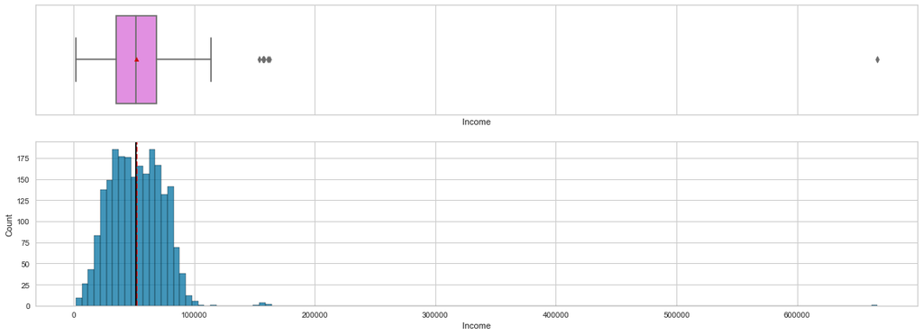

```python
histogram_boxplot(data, 'Income')
```

#### **Observations and Insights:**

Visualizing the **Income** distribution with the histogram and boxplot stacked on top of each other shows clearly that there is an **extreme outlier** on the right. This would be the max income of 666,666 - which is an unusual number. This could be the result of a **data input error** or a deliberate misinformation by the customer to not divulge their annual income.

There is no value between that datapoint and the next lowest which is around 150,000.

We will remove this datapoint.

```python
data[data['Income'] > 600000]
```

|  | Year_Birth | Education | Marital_Status | Income | Kidhome | Teenhome | Dt_Customer | Recency | Wine | Fruits | ... | NumCatalogPurchases | NumStorePurchases | NumWebVisitsMonth | Camp3 | Camp4 | Camp5 | Camp1 | Camp2 | Complain | Camp6 |
| --- | --- | --- | --- | --- | --- | --- | --- | --- | --- | --- | --- | --- | --- | --- | --- | --- | --- | --- | --- | --- | --- |
| 2233 | 1977 | Graduation | Together | 666666.0 | 1 | 0 | 02-06-2013 | 23 | 9 | 14 | ... | 1 | 3 | 6 | 0 | 0 | 0 | 0 | 0 | 0 | 0 |

1 rows × 26 columns

```python
# Dropping the extreme value

data = data.drop(data[data['Income'] > 600000].index)
```

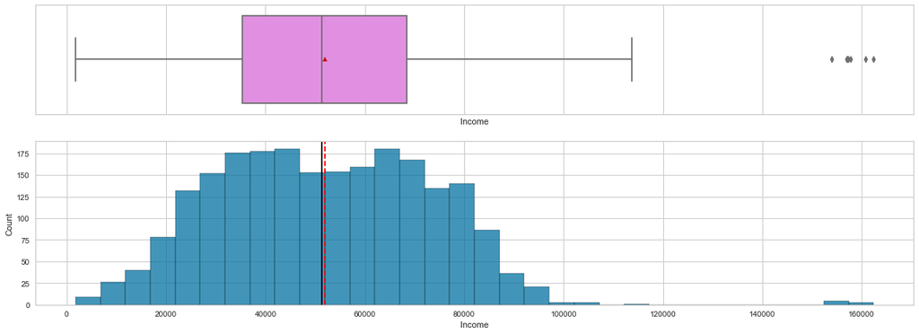

```python
# Checking again the outcome of the histogram and boxplot with 1 outlier removed

histogram_boxplot(data, 'Income')
```

- Without that extreme 1 datapoint of Income over 600k, **we still see a few outliers on the right**.

```python
# Calculating the upper whisker for the Income variable

Q1 = data.quantile(q=0.25)                          # Finding the first quartile

Q3 = data.quantile(q=0.75)                          # Finding the third quartile

IQR = Q3-Q1                                         # Finding the Inter Quartile Range

upper_whisker = (Q3 + 1.5 * IQR)['Income']          # Calculating the Upper Whisker for the Income variable

print("The Upper Whisker value is:", upper_whisker) # Printing Upper Whisker
```

```
The Upper Whisker value is: 118291.5
```

```python
# Let's check the observations with extreme value for the Income variable.

data[data['Income'] > upper_whisker]
```

|  | Year_Birth | Education | Marital_Status | Income | Kidhome | Teenhome | Dt_Customer | Recency | Wine | Fruits | ... | NumCatalogPurchases | NumStorePurchases | NumWebVisitsMonth | Camp3 | Camp4 | Camp5 | Camp1 | Camp2 | Complain | Camp6 |
| --- | --- | --- | --- | --- | --- | --- | --- | --- | --- | --- | --- | --- | --- | --- | --- | --- | --- | --- | --- | --- | --- |
| 164 | 1973 | PhD | Married | 157243.0 | 0 | 1 | 01-03-2014 | 98 | 20 | 2 | ... | 22 | 0 | 0 | 0 | 0 | 0 | 0 | 0 | 0 | 0 |
| 617 | 1976 | PhD | Together | 162397.0 | 1 | 1 | 03-06-2013 | 31 | 85 | 1 | ... | 0 | 1 | 1 | 0 | 0 | 0 | 0 | 0 | 0 | 0 |
| 655 | 1975 | Graduation | Divorced | 153924.0 | 0 | 0 | 07-02-2014 | 81 | 1 | 1 | ... | 0 | 0 | 0 | 0 | 0 | 0 | 0 | 0 | 0 | 0 |
| 687 | 1982 | PhD | Married | 160803.0 | 0 | 0 | 04-08-2012 | 21 | 55 | 16 | ... | 28 | 1 | 0 | 0 | 0 | 0 | 0 | 0 | 0 | 0 |
| 1300 | 1971 | Master | Together | 157733.0 | 1 | 0 | 04-06-2013 | 37 | 39 | 1 | ... | 0 | 1 | 1 | 0 | 0 | 0 | 0 | 0 | 0 | 0 |
| 1653 | 1977 | Graduation | Together | 157146.0 | 0 | 0 | 29-04-2013 | 13 | 1 | 0 | ... | 28 | 0 | 1 | 0 | 0 | 0 | 0 | 0 | 0 | 0 |
| 2132 | 1949 | PhD | Married | 156924.0 | 0 | 0 | 29-08-2013 | 85 | 2 | 1 | ... | 0 | 0 | 0 | 0 | 0 | 0 | 0 | 0 | 0 | 0 |

7 rows × 26 columns

```python
# Check the 99.7% percentile (3SD) value for the Income variable
Three_SD = data.quantile(q=0.997)['Income']

print('The 3 Standard Deviation value is:', Three_SD)
```

```
The 3 Standard Deviation value is: 128122.02000000702
```

```python
# Let's check the observations with extreme value for the Income variable

data[data.Income > Three_SD]
```

|  | Year_Birth | Education | Marital_Status | Income | Kidhome | Teenhome | Dt_Customer | Recency | Wine | Fruits | ... | NumCatalogPurchases | NumStorePurchases | NumWebVisitsMonth | Camp3 | Camp4 | Camp5 | Camp1 | Camp2 | Complain | Camp6 |
| --- | --- | --- | --- | --- | --- | --- | --- | --- | --- | --- | --- | --- | --- | --- | --- | --- | --- | --- | --- | --- | --- |
| 164 | 1973 | PhD | Married | 157243.0 | 0 | 1 | 01-03-2014 | 98 | 20 | 2 | ... | 22 | 0 | 0 | 0 | 0 | 0 | 0 | 0 | 0 | 0 |
| 617 | 1976 | PhD | Together | 162397.0 | 1 | 1 | 03-06-2013 | 31 | 85 | 1 | ... | 0 | 1 | 1 | 0 | 0 | 0 | 0 | 0 | 0 | 0 |
| 655 | 1975 | Graduation | Divorced | 153924.0 | 0 | 0 | 07-02-2014 | 81 | 1 | 1 | ... | 0 | 0 | 0 | 0 | 0 | 0 | 0 | 0 | 0 | 0 |
| 687 | 1982 | PhD | Married | 160803.0 | 0 | 0 | 04-08-2012 | 21 | 55 | 16 | ... | 28 | 1 | 0 | 0 | 0 | 0 | 0 | 0 | 0 | 0 |
| 1300 | 1971 | Master | Together | 157733.0 | 1 | 0 | 04-06-2013 | 37 | 39 | 1 | ... | 0 | 1 | 1 | 0 | 0 | 0 | 0 | 0 | 0 | 0 |
| 1653 | 1977 | Graduation | Together | 157146.0 | 0 | 0 | 29-04-2013 | 13 | 1 | 0 | ... | 28 | 0 | 1 | 0 | 0 | 0 | 0 | 0 | 0 | 0 |
| 2132 | 1949 | PhD | Married | 156924.0 | 0 | 0 | 29-08-2013 | 85 | 2 | 1 | ... | 0 | 0 | 0 | 0 | 0 | 0 | 0 | 0 | 0 | 0 |

7 rows × 26 columns

#### **Observations and Insights:**

- There are 7 rows where **Income** is above the **99.7th percentile** (3 SD from the mean). We can drop these extreme values since they are less than **1% of the dataset**.

```python
# Dropping observations identified as outliers

# Pass the indices of the observations (separated by a comma) to drop them

index = [164, 617, 655, 687, 1300, 1653, 2132]
for i in index:
   data.drop(index = i, inplace = True)
```

**Now, let's check the distribution of the Income variable after dropping outliers.**

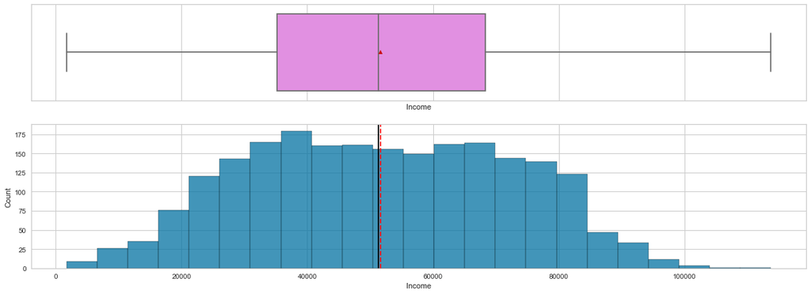

```python
# Plot histogram and 'Income'
histogram_boxplot(data, 'Income')
```

- We now have an **Income** distribution that is more normally distributed.

```python
# Creating a numeric columns list to display boxplots to view outliers
numeric_cols = data.select_dtypes(include=['number']).columns

numeric_cols
```

```
Index(['Year_Birth', 'Income', 'Kidhome', 'Teenhome', 'Recency', 'Wine',
       'Fruits', 'Meat', 'Fish', 'Sweets', 'Gold', 'NumDealsPurchases',
       'NumWebPurchases', 'NumCatalogPurchases', 'NumStorePurchases',
       'NumWebVisitsMonth', 'Camp3', 'Camp4', 'Camp5', 'Camp1', 'Camp2',
       'Complain', 'Camp6'],
      dtype='object')
```

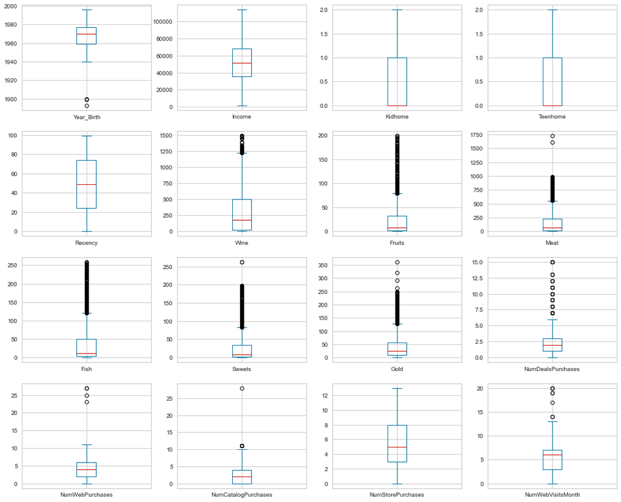

```python
#Dropping the campaign acceptance data since they are 1 and 0s
numeric_cols = numeric_cols.drop(['Camp1', 'Camp2', 'Camp3', 'Camp4','Camp5', 'Camp6', 'Complain'])

#Plotting boxplots at a glance
data[numeric_cols].plot(subplots=True, layout=(4,4), kind='box', figsize=(18,15))

plt.show()
```

- We can see quite a few outliers in the **product** and **retail channel** categories. Let us examine these individually with their histogram and boxplot.

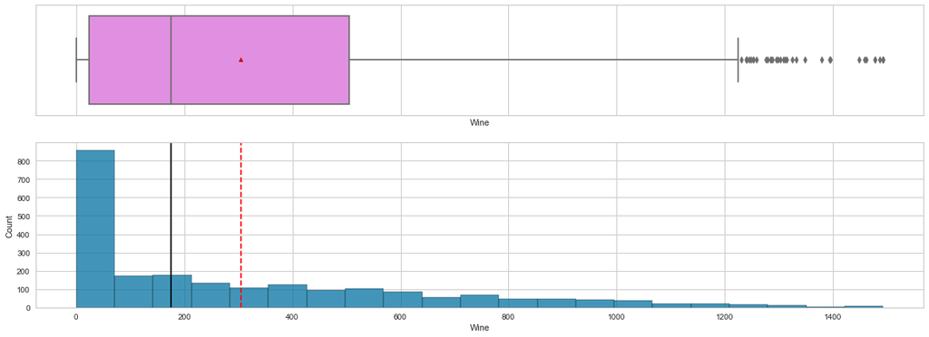

```python
# Plot the histogram for 'Wine'

histogram_boxplot(data, 'Wine')
```

```python
data['Wine'].describe()
```

```
count    2232.000000
mean      304.930108
std       336.784950
min         0.000000
25%        24.000000
50%       176.000000
75%       505.000000
max      1493.000000
Name: Wine, dtype: float64
```

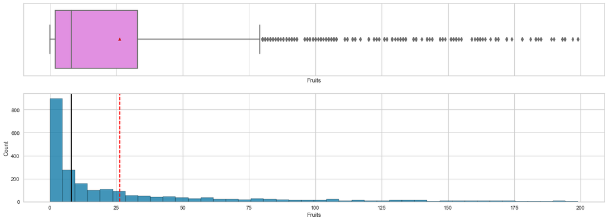

```python
# Plot the histogram for 'Fruits'

histogram_boxplot(data, 'Fruits')
```

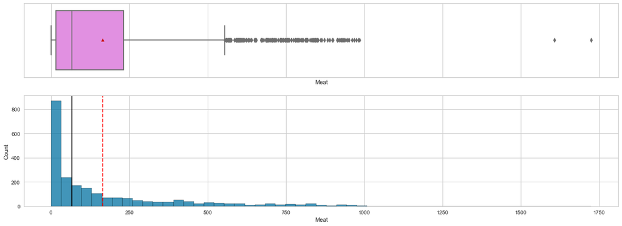

```python
# Plot the histogram for 'Meat' Products

histogram_boxplot(data, 'Meat')
```

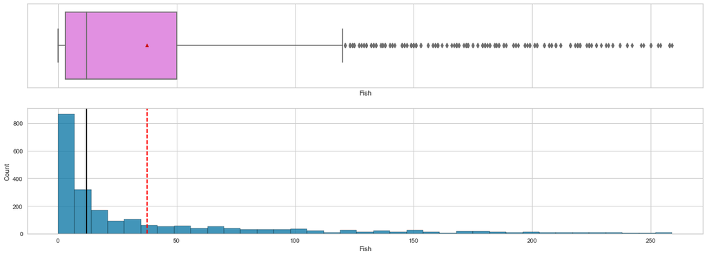

```python
# Plot the histogram for 'Fish' Products

histogram_boxplot(data, 'Fish')
```

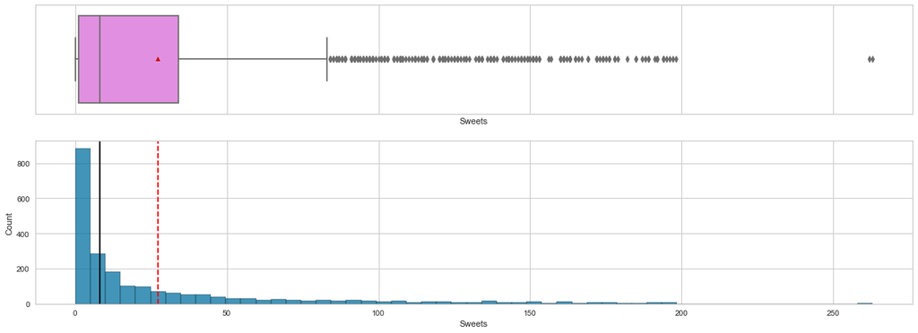

```python
# Plot the histogram for 'Sweets' Products

histogram_boxplot(data, 'Sweets')
```

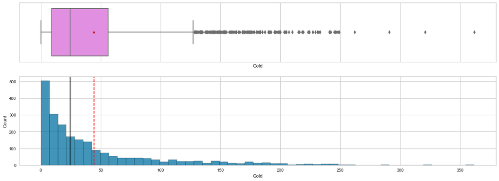

```python
# Plot the histogram for 'Gold' products


histogram_boxplot(data, 'Gold')
```

**Observation and Insights for all Product plots**

- All the product category show **significant rightward skew**, which would make sense because the most frequent purchases would be smaller vs fewer larger purchases.
- There are a few extreme outliers in **Meat**, **Sweets** and **Gold**.

#### **Note:** Try plotting histogram for different numerical features and understand how the data looks like.

## **2. Univariate analysis - Categorical Data**

Let us write a function that will help us create bar plots that indicate the percentage for each category. This function takes the categorical column as the input and returns the bar plot for the variable.

```python
def perc_on_bar(z):
    '''
    plot
    feature: categorical feature
    the function won't work if a column is passed in hue parameter
    '''

    total = len(data[z])                                          # Length of the column
    plt.figure(figsize=(12,5))
    ax = sns.countplot(data[z],palette='Paired',order = data[z].value_counts().index)
    for p in ax.patches:
        percentage = '{:.1f}%'.format(100 * p.get_height()/total) # Percentage of each class of the category
        x = p.get_x() + p.get_width() / 2 - 0.05                  # Width of the plot
        y = p.get_y() + p.get_height()                            # Height of the plot

        ax.annotate(percentage, (x, y), size = 13)                # Annotate the percentage

    plt.show()                                                    # Show the plot
```

#### Let us plot barplot for the variable Marital_Status.

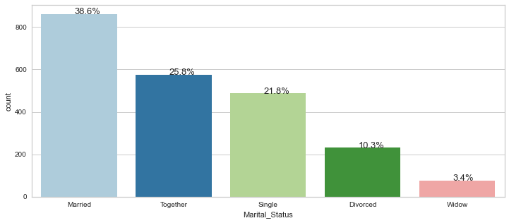

```python
# Bar plot for 'Marital_Status'
perc_on_bar('Marital_Status')
```

- 65% of customers are either Married or Together - we can combine these categories
- 35% of customers are either Single, Divorced or Widow -we can assume that they are not in a relationship and are single-incomed.

#### **Note:** Explore for other categorical variables like Education, Kidhome, Teenhome, Complain.

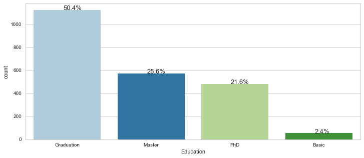

```python
# Bar plot for 'Education'
perc_on_bar('Education')
```

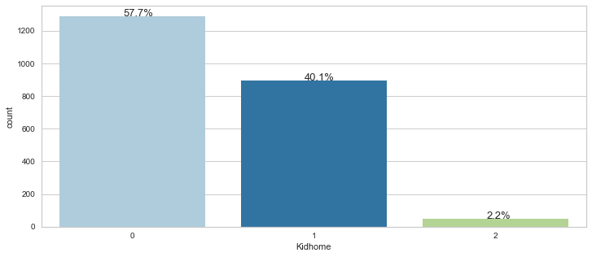

```python
# Bar plot for 'Kidhome'
perc_on_bar('Kidhome')
```

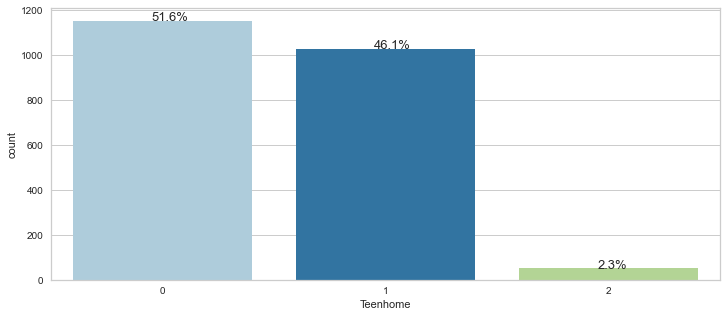

```python
# Bar plot for 'Teenhome'
perc_on_bar('Teenhome')
```

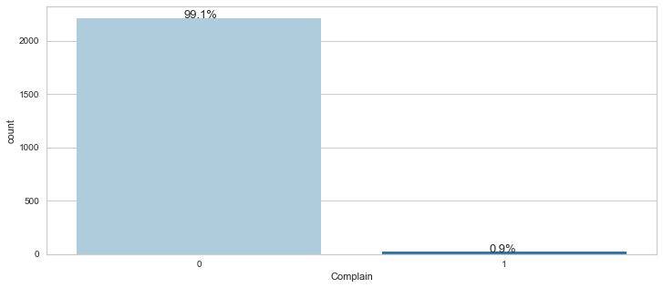

```python
# Bar plot for 'Complain'
perc_on_bar('Complain')
```

#### **Observations and Insights from all plots:**

- **Marital Status** - 65% of customers are either Married or Together. The people on their own make up the remainder (**Single**, **Divorce**, **Widow**)
- A high percentage of the customer base has higher education or better.
- Majority of customers have no kids or teens at home.
- **99%** of customers have not complained, which shows a high customer satisfaction - This may not be relevant to our analysis so we can consider dropping this column

## **Bivariate Analysis**

We have analyzed different categorical and numerical variables. Now, let's check how different variables are related to each other.

### **Correlation Heat map**

Heat map can show a 2D correlation matrix between numerical features.

```python
#Creating a columns list with numerical features
cols_list = data.select_dtypes(include = np.number).columns.tolist()

cols_list
```

```
['Year_Birth',
 'Income',
 'Kidhome',
 'Teenhome',
 'Recency',
 'Wine',
 'Fruits',
 'Meat',
 'Fish',
 'Sweets',
 'Gold',
 'NumDealsPurchases',
 'NumWebPurchases',
 'NumCatalogPurchases',
 'NumStorePurchases',
 'NumWebVisitsMonth',
 'Camp3',
 'Camp4',
 'Camp5',
 'Camp1',
 'Camp2',
 'Complain',
 'Camp6']
```

Let's take out the 'Complain' column from the heatmap since it only represents 1% of the data.

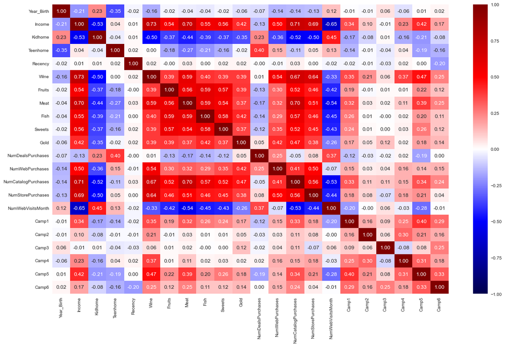

```python
#cols_list = data.select_dtypes(include = np.number).columns.tolist()
cols_list_2 = ['Year_Birth',
 'Income',
 'Kidhome',
 'Teenhome',
 'Recency',
 'Wine',
 'Fruits',
 'Meat',
 'Fish',
 'Sweets',
 'Gold',
 'NumDealsPurchases',
 'NumWebPurchases',
 'NumCatalogPurchases',
 'NumStorePurchases',
 'NumWebVisitsMonth',
 'Camp1',
 'Camp2',
 'Camp3',
 'Camp4',
 'Camp5',
 'Camp6']

#Plotsize
plt.figure(figsize=(20, 12))

 # Plotting the correlation plot
sns.heatmap(
    data[cols_list_2].corr(), annot=True, vmin=-1, vmax=1, fmt=".2f", cmap="seismic"
)


plt.show()
```

#### **Observations and Insights:**

- We can see a **high positive correlation** - between the following variables:
  - **Income** and the spend per product categories, which makes sense
  - and amongst this group, the highest positive correlation is **wine (0.73)** and **meat (0.70)** products - makes sense that customers with higher income tend to purchase higher value products
  - **Income** and **NumCatalogPurchases (0.71)** (mail catalog)
  - **Income** and **NumStorePurchases (0.69)**
  - **NumWebPurchase** highest with **Wine (0.54)** amongst products
  - **NumCatalogPurchase** highest with **Meat (0.70)** and **Wine (0.67)**
  - Many variables amongst the product category show a positive correlation to each other - which makes sense
  - **Kidhome** with **Discount** purchase - showing that customers with children are more discount sensitive
- We can see a **negative correlation** between the following variables:
  - **Kidhome** and amount of products purchased
  - **Kidhome** and catalog, web and in-store purchase
  - **NumWebVisits** and **Income (-0.65)**
  - **NumWebVisits** and amount of product purchased
  - **NumWebVisits** and **NumCatalogPurchases** - showing that customers either use one channel or the other
- On the **Marketing Campaigns**, we could make some assumptions that:
  - **Campaign 1**: had best results with Wine (0.35) and Meat (0.32)
  - **Campaign 2**: results were not very good - Wine was the best but only 0.21
  - **Campaign 3**: had even worse result than Campaign 2
  - **Campaign 4**: was targeted towards Wine buyer (0.37)
  - **Campaign 5**: had the best results and was especially targeted towards Wine buyers (0.47)
  - **Final Campaign (Campaign 6)**: again not great results either.

**The above correlation heatmap only shows the relationship between numerical variables. Let's check the relationship of numerical variables with categorical variables.**

### **Education Vs Income**

```
AxesSubplot(0.125,0.125;0.775x0.755)
```

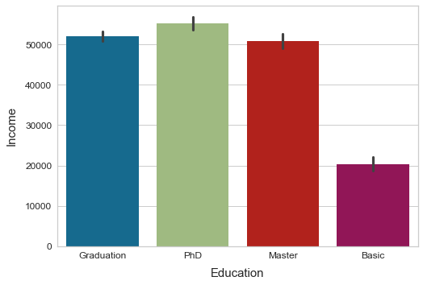

```python
print(sns.barplot(x= 'Education', y= 'Income', data=data, ci = 95))
plt.xticks(fontsize=12)                                   # Font size of X-label
plt.yticks(fontsize=12)                                   # Font size of Y-label
plt.xlabel("Education", fontsize=15, labelpad=10)         # Title of X-axis
plt.ylabel("Income", fontsize=15, labelpad=10)            # Title of Y-axis
```

```python
data['Education'].value_counts()
```

```
Graduation    1124
Master         572
PhD            482
Basic           54
Name: Education, dtype: int64
```

#### **Observations and Insights:**

- Customers who have **Higher Education** (Graduation, Master & PhD) earn **over 50,000 a year in annual income**, with PhD educated customers earning the highest .
- Customers with **Basic Education** earn much lower annual income of **20,000 a year**

### **Marital Status Vs Income**

```
AxesSubplot(0.125,0.125;0.775x0.755)
```

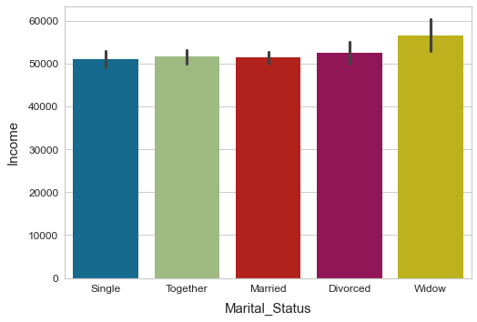

```python
# Plot the bar plot for Marital_Status and Income
print(sns.barplot(x= 'Marital_Status', y= 'Income', data=data, ci = 95))
plt.xticks(fontsize=12)                                   # Font size of X-label
plt.yticks(fontsize=12)                                   # Font size of Y-label
plt.xlabel("Marital_Status", fontsize=15, labelpad=10)    # Title of X-axis
plt.ylabel("Income", fontsize=15, labelpad=10)            # Title of Y-axis
```

#### **Observations and Insights:**

- All relationship status of customers earn above 50,000.
- **Widowers** have the highest annual income

### **Kidhome Vs Income**

```
AxesSubplot(0.125,0.125;0.775x0.755)
```

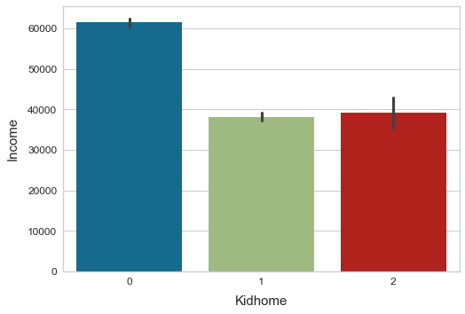

```python
# Plot the bar plot for Kidhome and Income

print(sns.barplot(x= 'Kidhome', y= 'Income', data=data, ci = 95))
plt.xticks(fontsize=12)                                   # Font size of X-label
plt.yticks(fontsize=12)                                   # Font size of Y-label
plt.xlabel("Kidhome", fontsize=15, labelpad=10)           # Title of X-axis
plt.ylabel("Income", fontsize=15, labelpad=10)            # Title of Y-axis
```

#### **Observations and Insights:**

- Customers without kids earn the highest average income - around 60,000
- Customers with 1 and 2 children at home earn below 40,000, on average.

**We can also visualize the relationship between two categorical variables.**

### **Marital_Status Vs Kidhome**

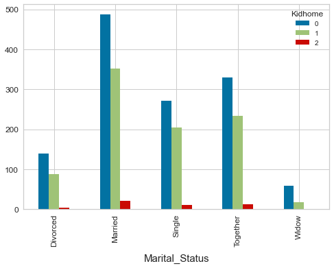

```python
# Plot the bar plot for Marital_Status and Kidhome
pd.crosstab(data['Marital_Status'], data['Kidhome']).plot(kind='bar',stacked=False)
plt.xticks(fontsize=12)                                   # Font size of X-label
plt.yticks(fontsize=12)                                   # Font size of Y-label
plt.xlabel("Marital_Status", fontsize=15, labelpad=10)     # Title of X-axis
```

#### **Observations and Insights:**

- In each of the category of marital status, most customers have 0 kids, followed by 1 kid and a few have 2 kids at home

## **Feature Engineering and Data Processing**

In this section, we will first prepare our dataset for analysis.

- Creating new columns
- Imputing missing values

The `Year_Birth` column in its current format is not useful in our analysis. We need to convert this to the age of the customer.

### **Age**

```python
# Extract only the year from the Year_Birth variable and subtracting it from 2016 will give us the age of the customer at the time of data collection in 2016

data["Age"] = 2016 - pd.to_datetime(data['Year_Birth'], format="%Y").apply(lambda x: x.year)

# Sorting the values in ascending order
data["Age"].sort_values()
```

```
1170     20
46       20
696      21
747      21
1850     21
       ...
424      75
1950     76
192     116
339     117
239     123
Name: Age, Length: 2232, dtype: int64
```

#### **Observations and Insights:**

- There are **3 customers aged > 115 years** - outliers which could be the result of data input error. We can drop these rows.
- The youngest customers are in their early 20s

```python
# Drop the observations with age > 115
# Hint: Use drop() method with inplace=True

data = data.drop(data[data['Age'] > 115].index)
```

**Now, let's check the distribution of Age in the data.**

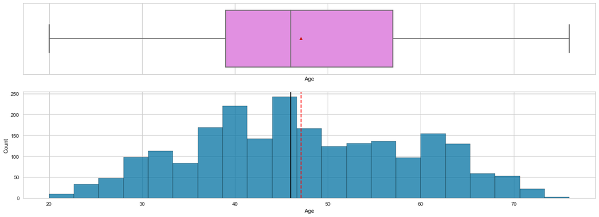

```python
# Plot histogram to check the distribution of age

histogram_boxplot(data, 'Age')
```

```python
data['Age'].describe()
```

```
count    2229.000000
mean       47.111261
std        11.707430
min        20.000000
25%        39.000000
50%        46.000000
75%        57.000000
max        76.000000
Name: Age, dtype: float64
```

#### **Observations and Insights:**

- After data cleaning, we now see the **Age** range of the customers from **20 to 76**. It also follows a normal distribution with a mean of 47.
- 50% of customers are between 39 and 57 years of age

### **Kids**

- Let's create feature "Kids" indicating the total kids and teens in the home.

```python
# Add Kidhome and Teenhome variables to create the new feature called "Kids"

data["Kids"] = data["Kidhome"]+data["Teenhome"]
```

```
AxesSubplot(0.125,0.125;0.775x0.755)
```

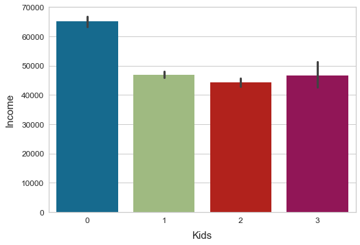

```python
print(sns.barplot(x= 'Kids', y= 'Income', data=data, ci = 95))
plt.xticks(fontsize=12)                                   # Font size of X-label
plt.yticks(fontsize=12)                                   # Font size of Y-label
plt.xlabel("Kids", fontsize=15, labelpad=10)              # Title of X-axis
plt.ylabel("Income", fontsize=15, labelpad=10)            # Title of Y-axis
```

### **Family Size**

- Let's create a new variable called **'Family Size'** to find out how many members each family has.
- For this, we need to have a look at the Marital_Status variable, and see what are the categories.

```python
# Check the unique categories in Marital_Status
data['Marital_Status'].unique()
```

```
array(['Single', 'Together', 'Married', 'Divorced', 'Widow'], dtype=object)
```

```python
data['Marital_Status'].value_counts()
```

```
Married     861
Together    575
Single      486
Divorced    230
Widow        77
Name: Marital_Status, dtype: int64
```

- We can combine the sub-categories Single, Divorced, Widow as **"Single"** and we can combine the sub-categories Married and Together as **"Relationship"**
- Then we can create a new variable called **"Status"** and assign **values 1 and 2** to categories Single and Relationship, respectively.
- Then, we can use the Kids (calculated above) and the Status column to find the family size.

```python
# Replace "Married" and "Together" with "Relationship"

data['Marital_Status'].replace(['Married', 'Together'], 'Relationship', inplace = True)
```

```python
# Replace "Divorced" and "Widow" with "Single"

data['Marital_Status'].replace(['Divorced', 'Widow'], 'Single', inplace = True)
```

```python
# Create a new feature called "Status" by replacing "Single" with 1 and "Relationship" with 2 in Marital_Status

data["Status"] = data['Marital_Status'].replace({'Single': 1, 'Relationship': 2})

data['Status'].value_counts()
```

```
2    1436
1     793
Name: Status, dtype: int64
```

```python
# Add two variables Status and Kids to get the total number of persons in each family

data["Family_Size"] = data["Status"]+data["Kids"]
```

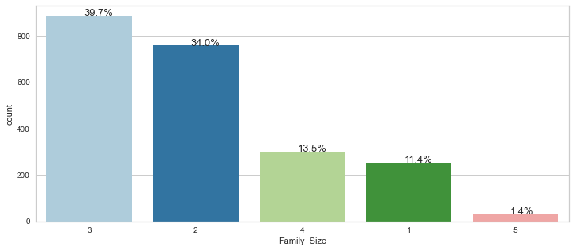

```python
perc_on_bar('Family_Size')
```

```
AxesSubplot(0.125,0.125;0.775x0.755)
```

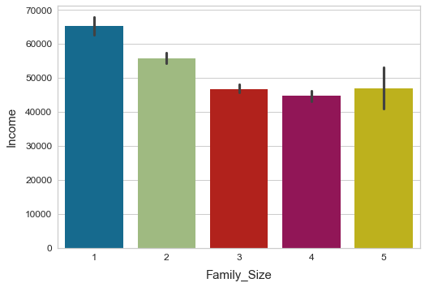

```python
print(sns.barplot(x= 'Family_Size', y= 'Income', data=data, ci = 95))

plt.xticks(fontsize=12)                                   # Font size of X-label
plt.yticks(fontsize=12)                                   # Font size of Y-label
plt.xlabel("Family_Size", fontsize=15, labelpad=10)       # Title of X-axis
plt.ylabel("Income", fontsize=15, labelpad=10)            # Title of Y-axis
```

We can observe that the majority of the customer base is between mid 30s to 60s, with a family size of 2 to 3, with annual income around 50,000.

### **Expenses**

- Let's create a new feature called **Expenses**, indicating the total amount spent by the customers in various products over the span of two years.

```python
# Create a new feature

# Add the amount spent on each of product 'Wine', 'Fruits', 'Meat', 'Fish', 'Sweet', 'Gold'

data["Expenses"] = data['Wine']+data['Fruits']+data['Meat']+data['Fish']+data['Sweets']+data['Gold']
```

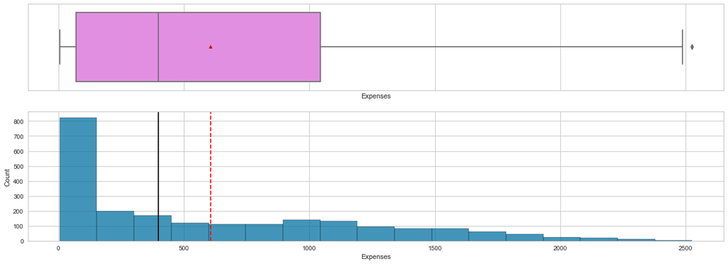

```python
# Plot histogram to check the distribution of 'Expenses'
histogram_boxplot(data, 'Expenses')
```

```python
data['Expenses'].describe()
```

```
count    2229.000000
mean      605.541050
std       601.032228
min         5.000000
25%        69.000000
50%       397.000000
75%      1044.000000
max      2525.000000
Name: Expenses, dtype: float64
```

### **Total Purchases**

- Let's create a new feature called **NumTotalPurchases**, indicating the total number of products purchased by the customers.

```python
# Create a new feature

# Add the number of purchases from each channel 'NumDealsPurchases', 'NumWebPurchases', 'NumCatalogPurchases', 'NumStorePurchases'

data["NumTotalPurchases"] = data['NumDealsPurchases']+data['NumWebPurchases']+data['NumCatalogPurchases']+data['NumStorePurchases']
```

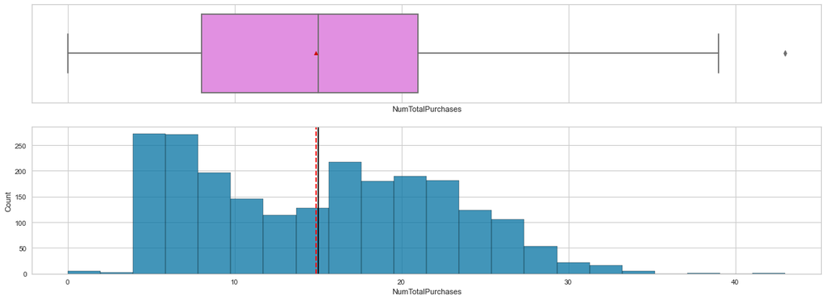

```python
# Plot histogram to check the distribution of 'NumTotalPurchases'
histogram_boxplot(data, 'NumTotalPurchases')
```

### **Engaged Days**

- Let's create a new feature called **Engaged_Days**, indicating how long the customer has been with the company.

```python
# Converting Dt_customer variable to Python date time object

data["Dt_Customer"] = pd.to_datetime(data['Dt_Customer'])
```

**Let's check the max and min of the date.**

```python
# Check the minimum of the date
# Hint: Use the min() method

print("The oldest customer enrollment date:", data['Dt_Customer'].min())
```

```
The oldest customer enrollment date: 2012-01-08 00:00:00
```

```python
# Check the maximum of the date
# Hint: Use the max() method

print("The newest customer enrollment date:", data['Dt_Customer'].max())
```

```
The newest customer enrollment date: 2014-12-06 00:00:00
```

We assign the date **January 1st, 2015** as the date threshold from which we calculate **Engaged Days**

```python
 # Assigning date to the day variable
data["day"] = "01-01-2015"

# Converting the variable day to Python datetime object
data["day"] = pd.to_datetime(data.day)

# Creating how long a customer has been engaged with the store for in days.
data["Engaged_Days"] = (data["day"] - data["Dt_Customer"]).dt.days
```

```python
# Checking summary information of the new variable 'Engaged_Days'
data['Engaged_Days'].describe()
```

```
count    2229.000000
mean      538.099148
std       232.287894
min        26.000000
25%       367.000000
50%       539.000000
75%       712.000000
max      1089.000000
Name: Engaged_Days, dtype: float64
```

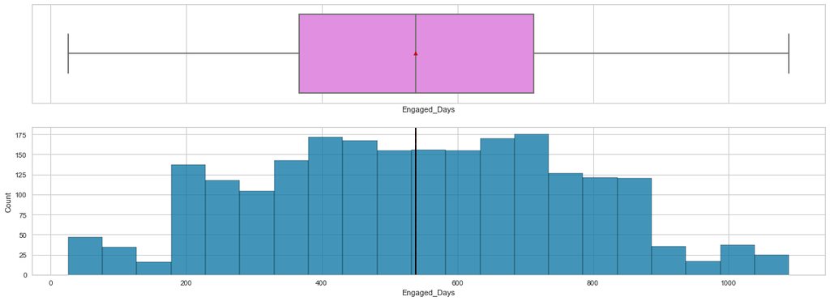

```python
# Plot histogram to check the distribution of 'Engaged_Days'
histogram_boxplot(data, 'Engaged_Days')
```

### **FishMeat**

- Let's create a new feature called **FishMeat** that combines Fish and Meat

```python
# Add Fish and Meat variables to get the total amount of protein purchased by a customer in the last two years.
# "Fish", "Meat"

data["FishMeat"] = data["Fish"]+data["Meat"]

data["FishMeat"].describe()
```

```
count    2229.000000
mean      202.926424
std       255.447924
min         1.000000
25%        21.000000
50%        80.000000
75%       306.000000
max      1726.000000
Name: FishMeat, dtype: float64
```

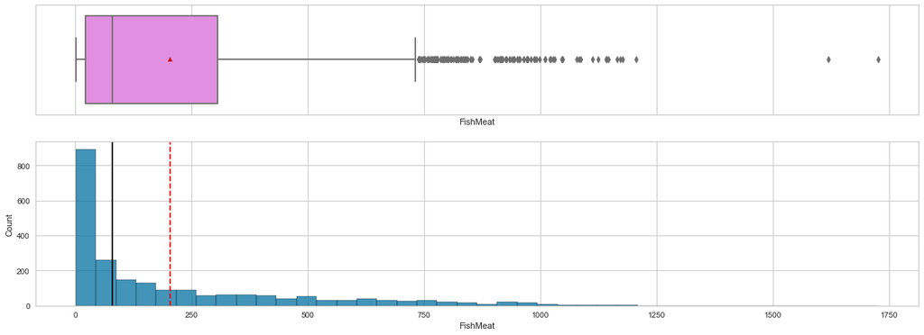

```python
# Plot the histogram for 'FishMeat'

histogram_boxplot(data, 'FishMeat')
```

### **Dessert**

- Let's create a new feature called **Dessert** that combines Fruits and Sweets

```python
# Add Sweets and Fruits variables to get the total amount of Dessert purchased by a customer in the last two years.
# "Sweets", "Fruits"

data["Dessert"] = data["Sweets"]+data["Fruits"]

data["Dessert"].describe()
```

```
count    2229.000000
mean       53.510094
std        71.782070
min         0.000000
25%         5.000000
50%        19.000000
75%        76.000000
max       378.000000
Name: Dessert, dtype: float64
```

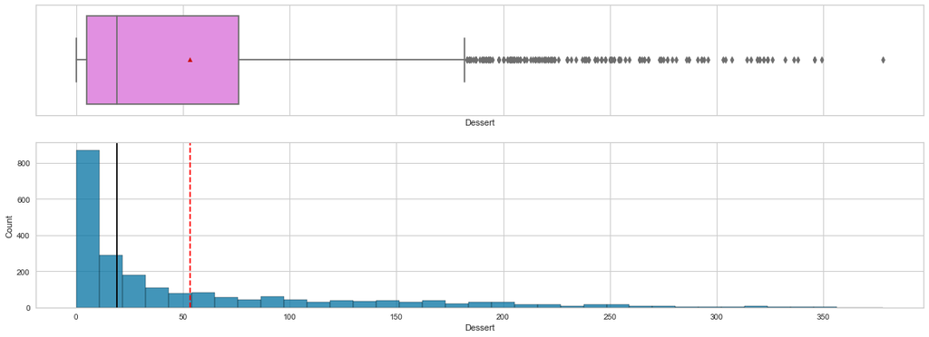

```python
# Plot the histogram for 'Dessert'

histogram_boxplot(data, 'Dessert')
```

### **TotalAcceptedCmp**

- Let's create a new feature called **TotalCamp** that shows how many total marketing campaign offers customers have accepted.

```python
# Add all the campaign related variables to get the total number of accepted campaigns by a customer
# "AcceptedCmp1", "AcceptedCmp2", "AcceptedCmp3", "AcceptedCmp4", "AcceptedCmp5", "Response"

data["TotalCamp"] = data["Camp1"]+data["Camp2"]+data["Camp3"]+data["Camp4"]+data["Camp5"]+data["Camp6"]

data['TotalCamp'].value_counts()
```

```
0    1621
1     369
2     142
3      51
4      37
5       9
Name: TotalCamp, dtype: int64
```

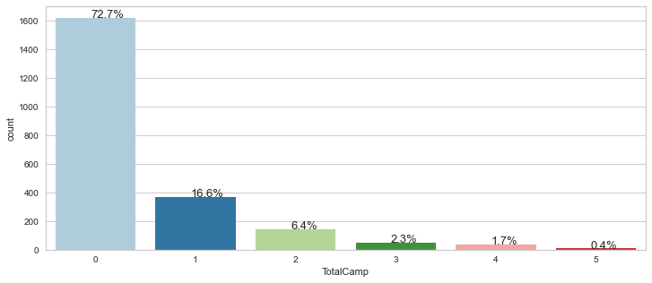

```python
perc_on_bar('TotalCamp')
```

- Over **70% of customers did not accept any of the campaigns**

```
AxesSubplot(0.125,0.125;0.775x0.755)
```

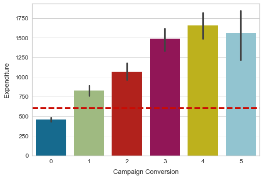

```python
print(sns.barplot(x= 'TotalCamp', y= 'Expenses', data=data, ci = 95))
plt.xticks(fontsize=12)                                         # Font size of X-label
plt.yticks(fontsize=12)                                         # Font size of Y-label
plt.xlabel("Campaign Conversion", fontsize=13, labelpad=10)        # Title of X-axis
plt.ylabel("Expenditure", fontsize=13, labelpad=10)                # Title of Y-axis
# Benchmark Mean values
plt.axhline(y=data['Expenses'].mean(), color='r', linestyle='--', linewidth=3)
```

### **AmountPerPurchase**

- Let's create a new feature called "AmountPerPurchase" indicating the amount spent per purchase.

```python
# Divide the "Expenses" by "NumTotalPurchases" to create a new feature, AmtPerPurchase

data['AmtPerPurchase'] = data['Expenses']/data['NumTotalPurchases']
```

**Now, let's check the maximum value of the AmountPerPurchase.**

```python
# Check the max value
# Hint: Use max() function
data['AmtPerPurchase'].max()
```

```
inf
```

The output above means 'infinity' and is the result of dividing a positive number by zero. This tells us that there are values = 0s in the data. Let's find out how many values there are.

```python
# Find how many observations have NumTotalPurchases equal to 0
count = (data['NumTotalPurchases'] == 0).sum()
count
```

```
2
```

Given that there are only 2 rows with value = 0, and given that the number of purchase is unlikely to be 0, we can assume this is an input error, and thus we can drop these.

```python
# Drop the observations with NumTotalPurchases equal to 0, using their indices

data = data[data['NumTotalPurchases'] != 0]
```

**Now, let's check the distribution of values in AmountPerPurchase column.**

```python
# Check the summary statistics of the AmountPerPurchase variable
data['AmtPerPurchase'].describe()
```

```
count    2227.000000
mean       33.274270
std        45.040897
min         0.533333
25%         9.714286
50%        23.352941
75%        45.281773
max      1679.000000
Name: AmtPerPurchase, dtype: float64
```

```python
data['AmtPerPurchase'].sort_values()
```

```
1245       0.533333
1846       0.600000
2129       2.000000
1420       2.000000
1819       2.250000
           ...
1749     148.733333
1001     158.416667
644      173.230769
1328     186.500000
2228    1679.000000
Name: AmtPerPurchase, Length: 2227, dtype: float64
```

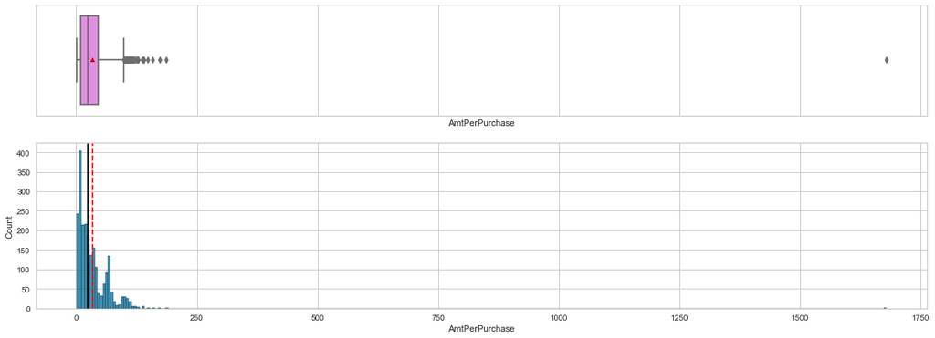

```python
# Plot the histogram for the AmountPerPurchase variable
histogram_boxplot(data, 'AmtPerPurchase')
```

#### **Observations and Insights:**

- There is one outlier datapoint very far on the right (where value=1679). We will remove this outlier.

```python
#Checking the datapoint for the outlier

data[data['AmtPerPurchase'] == 1679]
```

|  | Year_Birth | Education | Marital_Status | Income | Kidhome | Teenhome | Dt_Customer | Recency | Wine | Fruits | ... | Status | Family_Size | Expenses | NumTotalPurchases | day | Engaged_Days | FishMeat | Dessert | TotalCamp | AmtPerPurchase |
| --- | --- | --- | --- | --- | --- | --- | --- | --- | --- | --- | --- | --- | --- | --- | --- | --- | --- | --- | --- | --- | --- |
| 2228 | 1978 | Master | Relationship | NaN | 0 | 0 | 2012-12-08 | 53 | 32 | 2 | ... | 2 | 2 | 1679 | 1 | 2015-01-01 | 754 | 1619 | 6 | 1 | 1679.0 |

1 rows × 38 columns

```python
data = data.drop(data[data['AmtPerPurchase'] == 1679].index)
```

### **Imputing Missing Values**

```python
# Impute the missing values for the Income variable with the median

impute_median = data['Income'].median()

data['Income']=data['Income'].fillna(impute_median)
```

**Now that we are done with data preprocessing, let's visualize new features against the new income variable we have after imputing missing values.**